# F9_02_SIGNING_OFF_SIGNTR_DATE

Signing officer signature date · Date report

## Overview

**Description**

Date of Signing Officer’s Signature

**Table**

`F9-P02-T00-SIGNATURE` (one)

**Location code**

`F990-PC-PART-02`

**Family**

`F990-PC-PART-02` · siblings: F9_02_DISC_PREP_THIRD_PARTY_X, F9_02_PREP_FIRM_ADDR_CITY, F9_02_PREP_FIRM_ADDR_CNTR, F9_02_PREP_FIRM_ADDR_L1, F9_02_PREP_FIRM_ADDR_L2, F9_02_PREP_FIRM_ADDR_STATE

**Data type**

date (xsd: DateType)

**Scope**

SG

**Status**

unreviewed

2

xpaths mapped (2 observed)

5,981,036

filings with a value

2009–2024

tax years observed

0

open flags (0 errors)

## Flags

No open flags.

## Xpaths

All mapped xpaths (under /Return/ReturnData or /Return/ReturnHeader), oldest first. Charts label each series by its xpath.

| Xpath | Form | First year | Last year | Versions | Filings | Repeats in |
| --- | --- | --- | --- | --- | --- | --- |
| Officer/DateSigned | Header | 2009 | 2012 | 19 | 750,122 | 0.0% |
| BusinessOfficerGrp/SignatureDt | Header | 2013 | 2024 | 38 | 5,230,914 | 0.0% |

## Coverage

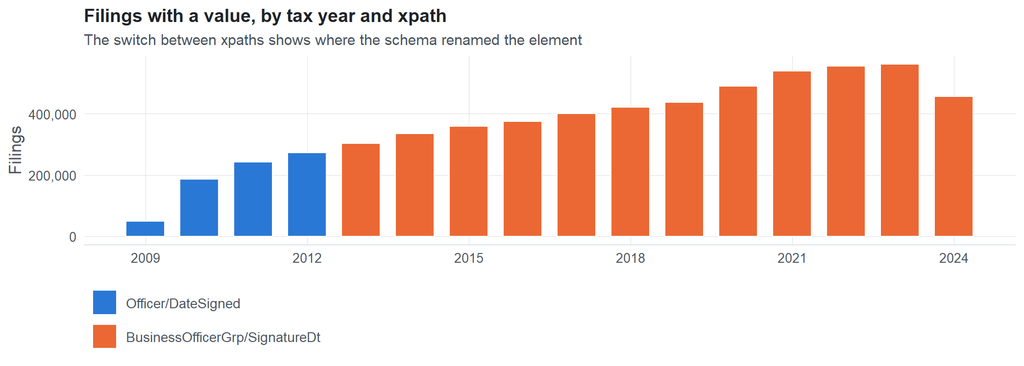

**Table view**

Table view: filings by tax year and series

| Tax year | Officer/DateSigned | BusinessOfficerGrp/SignatureDt |
| --- | --- | --- |
| 2009 | 48,781 | 0 |
| 2010 | 186,351 | 0 |
| 2011 | 241,552 | 0 |
| 2012 | 273,438 | 0 |
| 2013 | 0 | 303,230 |
| 2014 | 0 | 335,036 |
| 2015 | 0 | 358,413 |
| 2016 | 0 | 374,387 |
| 2017 | 0 | 400,757 |
| 2018 | 0 | 420,826 |
| 2019 | 0 | 436,317 |
| 2020 | 0 | 490,208 |
| 2021 | 0 | 539,217 |
| 2022 | 0 | 555,197 |
| 2023 | 0 | 561,156 |
| 2024 | 0 | 456,170 |

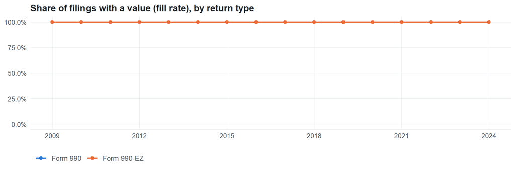

**Table view**

Table view: fill rate

| Tax year | Return type | Filings | All filings | Fill rate |
| --- | --- | --- | --- | --- |
| 2009 | Form 990 | 33,311 | 33,311 | 100.00% |
| 2009 | Form 990-EZ | 15,470 | 15,470 | 100.00% |
| 2010 | Form 990 | 123,025 | 123,025 | 100.00% |
| 2010 | Form 990-EZ | 63,326 | 63,326 | 100.00% |
| 2011 | Form 990 | 159,504 | 159,504 | 100.00% |
| 2011 | Form 990-EZ | 82,048 | 82,048 | 100.00% |
| 2012 | Form 990 | 179,688 | 179,688 | 100.00% |
| 2012 | Form 990-EZ | 93,750 | 93,750 | 100.00% |
| 2013 | Form 990 | 198,855 | 198,855 | 100.00% |
| 2013 | Form 990-EZ | 104,375 | 104,375 | 100.00% |
| 2014 | Form 990 | 218,619 | 218,619 | 100.00% |
| 2014 | Form 990-EZ | 116,417 | 116,417 | 100.00% |
| 2015 | Form 990 | 233,519 | 233,519 | 100.00% |
| 2015 | Form 990-EZ | 124,894 | 124,894 | 100.00% |
| 2016 | Form 990 | 243,903 | 243,903 | 100.00% |
| 2016 | Form 990-EZ | 130,484 | 130,484 | 100.00% |
| 2017 | Form 990 | 261,612 | 261,612 | 100.00% |
| 2017 | Form 990-EZ | 139,144 | 139,144 | 100.00% |
| 2018 | Form 990 | 271,442 | 271,442 | 100.00% |
| 2018 | Form 990-EZ | 149,384 | 149,384 | 100.00% |
| 2019 | Form 990 | 283,694 | 283,694 | 100.00% |
| 2019 | Form 990-EZ | 152,622 | 152,622 | 100.00% |
| 2020 | Form 990 | 320,342 | 320,342 | 100.00% |
| 2020 | Form 990-EZ | 169,864 | 169,864 | 100.00% |
| 2021 | Form 990 | 336,480 | 336,480 | 100.00% |
| 2021 | Form 990-EZ | 202,724 | 202,724 | 100.00% |
| 2022 | Form 990 | 349,055 | 349,055 | 100.00% |
| 2022 | Form 990-EZ | 206,130 | 206,130 | 100.00% |
| 2023 | Form 990 | 354,768 | 354,768 | 100.00% |
| 2023 | Form 990-EZ | 206,379 | 206,379 | 100.00% |
| 2024 | Form 990 | 277,298 | 277,298 | 100.00% |
| 2024 | Form 990-EZ | 178,867 | 178,867 | 100.00% |

## Values

| Result | Check | Detail |
| --- | --- | --- |
| ✓ pass | One date format | 100.0% use date (YYYY-MM-DD) |
| ⓘ info | Dates after the tax year | 16 of 16 tax years contain a date more than 3 years later (e.g. TY2013: 2201-04-11) |
| ⓘ info | Dates before 1900 | 1 of 16 tax years contain a date before 1900 (e.g. 1011-01-04) |

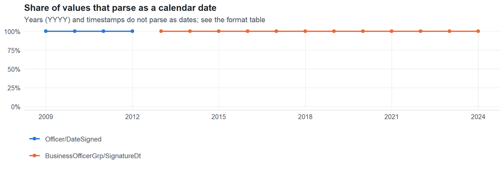

Formats (value shapes: 9 = digit, A = letter)

| Series | Shape | Format | Filings | Share |
| --- | --- | --- | --- | --- |
| Officer/DateSigned | 9999-99-99 | date (YYYY-MM-DD) | 750,122 | 100.0% |
| BusinessOfficerGrp/SignatureDt | 9999-99-99 | date (YYYY-MM-DD) | 5,230,914 | 100.0% |

**Table view**

Earliest and latest value by tax year

| Series | Tax year | Filings | Earliest | Latest |
| --- | --- | --- | --- | --- |
| Officer/DateSigned | 2009 | 48,781 | 1920-02-07 | 2912-12-18 |
| Officer/DateSigned | 2010 | 186,351 | 1011-01-04 | 6201-07-05 |
| Officer/DateSigned | 2011 | 241,552 | 1917-03-16 | 8201-03-19 |
| Officer/DateSigned | 2012 | 273,438 | 1920-04-19 | 4019-04-22 |
| BusinessOfficerGrp/SignatureDt | 2013 | 303,230 | 1920-02-15 | 2201-04-11 |
| BusinessOfficerGrp/SignatureDt | 2014 | 335,036 | 1920-01-12 | 8201-11-11 |
| BusinessOfficerGrp/SignatureDt | 2015 | 358,413 | 1917-01-27 | 5201-11-18 |
| BusinessOfficerGrp/SignatureDt | 2016 | 374,387 | 1917-05-12 | 3201-02-12 |
| BusinessOfficerGrp/SignatureDt | 2017 | 400,757 |  | 9189-08-28 |
| BusinessOfficerGrp/SignatureDt | 2018 | 420,826 | 1919-10-04 | 8202-05-15 |
| BusinessOfficerGrp/SignatureDt | 2019 | 436,317 |  | 8202-06-12 |
| BusinessOfficerGrp/SignatureDt | 2020 | 490,208 |  | 5021-05-16 |
| BusinessOfficerGrp/SignatureDt | 2021 | 539,217 |  | 8202-04-05 |
| BusinessOfficerGrp/SignatureDt | 2022 | 555,197 |  | 7202-01-01 |
| BusinessOfficerGrp/SignatureDt | 2023 | 561,156 |  | 7202-07-07 |
| BusinessOfficerGrp/SignatureDt | 2024 | 456,170 |  | 6202-12-16 |

## Examples

| Tax year | Return | Xpath | Organization | Value | Source |
| --- | --- | --- | --- | --- | --- |
| 2024 | 990 | BusinessOfficerGrp/SignatureDt | OWL CREEK COUNTRY CLUB | 2025-11-14 | [XML](https://gt990datalake-rawdata.s3.amazonaws.com/EfileData/XmlFiles/202513219349315726_public.xml) |
| 2023 | 990 | BusinessOfficerGrp/SignatureDt | ZEPF CENTER | 2024-12-03 | [XML](https://gt990datalake-rawdata.s3.amazonaws.com/EfileData/XmlFiles/202423399349300887_public.xml) |
| 2022 | 990 | BusinessOfficerGrp/SignatureDt | BRANDYWINE VFW POST 845 | 2023-06-13 | [XML](https://gt990datalake-rawdata.s3.amazonaws.com/EfileData/XmlFiles/202311649349300031_public.xml) |
| 2021 | 990 | BusinessOfficerGrp/SignatureDt | COULEE REGION HUMANE SOCIETY INC | 2022-09-28 | [XML](https://gt990datalake-rawdata.s3.amazonaws.com/EfileData/XmlFiles/202243119349301379_public.xml) |
| 2020 | 990 | BusinessOfficerGrp/SignatureDt | SOCIAL JUSTICE PUBLIC CHARTER SCHOOL | 2022-05-10 | [XML](https://gt990datalake-rawdata.s3.amazonaws.com/EfileData/XmlFiles/202201309349304660_public.xml) |
| 2019 | 990EZ | BusinessOfficerGrp/SignatureDt | CRESSKILL COUGARS UNITED SOCCER | 2020-10-23 | [XML](https://gt990datalake-rawdata.s3.amazonaws.com/EfileData/XmlFiles/202013089349200306_public.xml) |
| 2018 | 990 | BusinessOfficerGrp/SignatureDt | Coalition for Responsible Waste Incineration | 2019-09-10 | [XML](https://gt990datalake-rawdata.s3.amazonaws.com/EfileData/XmlFiles/201902539349301225_public.xml) |
| 2017 | 990EZ | BusinessOfficerGrp/SignatureDt | Three Roots International | 2018-08-06 | [XML](https://gt990datalake-rawdata.s3.amazonaws.com/EfileData/XmlFiles/201802189349200105_public.xml) |
| 2016 | 990 | BusinessOfficerGrp/SignatureDt | CHIROPRACTIC SOCIETY INC MASSACHUSETTS | 2017-12-18 | [XML](https://gt990datalake-rawdata.s3.amazonaws.com/EfileData/XmlFiles/201703529349300655_public.xml) |
| 2015 | 990 | BusinessOfficerGrp/SignatureDt | THE UNIVERSITY OF QUEENSLAND IN AMERICA | 2016-07-26 | [XML](https://gt990datalake-rawdata.s3.amazonaws.com/EfileData/XmlFiles/201622109349300832_public.xml) |
| 2014 | 990 | BusinessOfficerGrp/SignatureDt | JUDGES AND LAWYERS BREAST CANCER ALERT | 2016-04-26 | [XML](https://gt990datalake-rawdata.s3.amazonaws.com/EfileData/XmlFiles/201601249349301520_public.xml) |
| 2013 | 990 | BusinessOfficerGrp/SignatureDt | AMERICAN FRIENDS OF OUR ARMED FORCES | 2014-08-14 | [XML](https://gt990datalake-rawdata.s3.amazonaws.com/EfileData/XmlFiles/201422269349304432_public.xml) |

## Reviewer checklist

- The definition matches the form line and instructions for every xpath’s schema years.
- Every xpath pooled here measures the same thing on the 990 and 990-EZ (close enough for analysis).
- The coverage chart has no unexplained gaps or jumps between tax years.
- Each open flag is fixed, or accepted with a note in validation_log.csv.
- The format is consistent (date, year or timestamp) and matches the data type.
- The date is on the expected side of the tax period (e.g. signature date after the period ends, formation year before it).
- Extreme earliest/latest values are data-entry errors, not a mapping problem.

Record the review as a row in `inst/extdata/src/validation_log.csv` (variable_name, reviewer, date, status, note). Evidence built 2026-09-23 17:09:04 MST from the ef2 DuckDB builds, TY2009–2024.